# Resilience metrics with ResilienceCore.jl: beetles and riparian guilds

Author

Simon Frost

```julia
ENV["GKSwstype"] = "100"
using MatrixCommunityModels
using ResilienceCore
using LinearAlgebra, Printf, Statistics
using Plots
```

## Matrix communities in ResilienceCore’s terms

ResilienceCore.jl computes stability and resilience metrics that dispatch on what a matrix *means*: the Jacobian at a fixed point, a density-independent projection matrix, a periodic model. This package hands it three kinds of object:

- `linearise(c, n, env)`: the Jacobian of one step of a closed community at a fixed point `n`, as a `DiscreteJacobian`. With `period = k` it is the Jacobian of `k` steps at a point of a `k`-cycle.
- `periodic_operator(invader, pool, envs)`: the matrices of a rare invader over a cycle of environments, as a `PeriodicOperator`.
- `MCMState(c, n, env)`: a community at a fixed point with ResilienceCore’s community interface, so that its simulated press, removal and extinction experiments run unchanged.

For a discrete-time fixed point, ResilienceCore’s metrics are:

- `isstable`: whether every eigenvalue of `J` has modulus below one;
- `resilience`: `-ln ρ(J)`, the rate at which small perturbations die out per step;
- `reactivity`: `ln ‖J‖₂`, positive when some perturbation grows in the first step;
- `max_amplification`: the largest growth of any perturbation before it decays, and when.

## One beetle: a stable equilibrium that amplifies

The larva-pupa-adult (LPA) beetle of vignette 21, alone, with the rates of `TRIBOLIUM_EDMUNDS_2003`. The state is `[L, P, A]`, in two-week steps.

```julia
beetle(; mu_a = 0.02, cpa = 0.012 / 0.4) =
    flour_beetle(:castaneum; b = 10, mu_l = 0.2, mu_a = mu_a,
                 eats = [:castaneum => (larvae_eggs = 0.01 / 0.4, adults_eggs = 0.01 / 0.4, adults_pupae = cpa)])
one = beetle()
e = periodic_point(one, [30.0, 30, 100], nothing)
J = linearise(one, e.n, nothing)
(state = round.(e.n; digits = 1), stable = isstable(J), resilience = resilience(J),
 reactivity = reactivity(J), max_amplification = max_amplification(J))
```

```
(state = [36.7, 29.4, 92.2], stable = true, resilience = 0.06950822732957873, reactivity = 0.2977001026387896, max_amplification = (1.3467578381889962, 1))
```

The equilibrium is stable, but perturbations die out slowly (a resilience of 0.07 per step, so a perturbation takes about 33 steps to shrink tenfold), and the equilibrium is reactive: the worst perturbation grows by a factor of 1.3 over the first step before it decays.

## Raising adult mortality: cycles and chaos

Costantino et al. (1997) set adult mortality at 96% per two weeks in laboratory cultures and varied the rate at which adults eat pupae, `c_pa`, taking the LPA model through cycles and chaos. The same design with the rates above (illustrative; they are not the fitted values of that experiment):

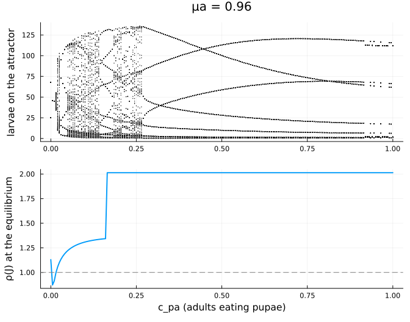

```julia
cpas = 0:0.005:1
attractor = map(cpas) do cpa
    c, x = beetle(mu_a = 0.96, cpa = cpa), [100.0, 100, 100]
    for _ in 1:500
        x = advance(c, x, nothing)
    end
    out = Float64[]
    for _ in 1:100
        x = advance(c, x, nothing)
        push!(out, x[1])
    end
    out
end
ρ = map(cpas) do cpa
    c = beetle(mu_a = 0.96, cpa = cpa)
    p = periodic_point(c, [50.0, 40, 30], nothing)
    maximum(abs, eigvals(operator(linearise(c, p.n, nothing))))
end
p1 = scatter(repeat(collect(cpas); inner = 100), reduce(vcat, attractor); ms = 0.8, msw = 0, color = :black,
             legend = false, ylabel = "larvae on the attractor", title = "μa = 0.96")
p2 = plot(cpas, ρ; lw = 2, legend = false, xlabel = "c_pa (adults eating pupae)",
          ylabel = "ρ(J) at the equilibrium")
hline!(p2, [1]; ls = :dash, color = :gray)
plot(p1, p2; layout = (2, 1), size = (700, 550))
```

A cycle is analysed in the same way, with the Jacobian of one pass around it. Its eigenvalues are the cycle’s multipliers (those of `periodic_point`), and its resilience per step is that of the period map divided by the period:

```julia
function cycle(cpa, k)
    c, x = beetle(mu_a = 0.96, cpa = cpa), [100.0, 100, 100]
    for _ in 1:600
        x = advance(c, x, nothing)
    end
    p = periodic_point(c, x, nothing; period = k)
    Jk = linearise(c, p.n, nothing; period = k)
    return (c_pa = cpa, period = k, converged = p.converged, stable = isstable(Jk),
            resilience_per_step = resilience(Jk) / k)
end
[cycle(0.0, 2), cycle(0.5, 8), cycle(1.0, 3)]
```

```
3-element Vector{@NamedTuple{c_pa::Float64, period::Int64, converged::Bool, stable::Bool, resilience_per_step::Float64}}:
 (c_pa = 0.0, period = 2, converged = 1, stable = 1, resilience_per_step = 0.09598213936806506)
 (c_pa = 0.5, period = 8, converged = 1, stable = 1, resilience_per_step = 0.11181756035238047)
 (c_pa = 1.0, period = 3, converged = 1, stable = 1, resilience_per_step = 0.07646747962920593)
```

All three cycles are stable, each settling at a rate comparable to the stable equilibrium of the long-lived beetle above.

## Two beetles: presses and removals

`MCMState` gives a community the interface that ResilienceCore’s simulated experiments use. Pressing a species multiplies the mortality hazard of every one of its stages: a stage that survives a step with probability `σ` survives with probability `σ^f`. Removing a species holds its stages at zero. After each perturbation the community returns to a fixed point.

The two-species model of Edmunds et al. (2003) has a stable coexistence equilibrium when larvae eat a moderate share of the other species’ eggs (region A of that paper):

```julia
two = flour_beetle_competition(merge(TRIBOLIUM_EDMUNDS_2003, (c_el = [0.01 0.018; 0.018 0.01],)))
s = MCMState(two, periodic_point(two, [8.0, 6, 34, 21, 17, 69], nothing).n, nothing)
(species = species_names(two), abundance = round.(state(s); digits = 1), stable = isstable(linearise(s)),
 local_tolerance = local_mortality_tolerances(s), global_tolerance = global_mortality_tolerance(s))
```

```
(species = [:confusum, :castaneum], abundance = [49.0, 107.3], stable = true, local_tolerance = [0.1, 0.30000000000000004], global_tolerance = 6.101000000000001)
```

`local_mortality_tolerances` is the smallest increase in one species’ mortality, in steps of 10%, that loses any species; `global_mortality_tolerance` the smallest multiplier of every species’ mortality that does. *T. confusum* is lost when its own mortality rises by 10%, yet no species is lost until the mortality of both rises 6.1-fold: a press on one species alone tips the competition, a press on both does not. Removing either species releases the other:

```julia
[(removed = species_names(two)[i], left = round.(state(without_species(s, i)); digits = 1))
 for i in present_species(s)]
```

```
2-element Vector{@NamedTuple{removed::Symbol, left::Vector{Float64}}}:
 (removed = :confusum, left = [0.0, 158.3])
 (removed = :castaneum, left = [163.7, 0.0])
```

## Riparian guilds in a constant flood regime

The five riparian guilds of vignette 3 compete for free space, and floods and droughts kill stage-specific fractions of each. The experiments need a fixed point, so each kind of year is held constant here, which removes the fluctuations the guilds normally live with:

```julia
rip = riparian_model(corrected = true)
flood_year = first(e for e in rip.envs if e.flood == 1)
dry_year = first(e for e in rip.envs if e.flood == 0 && e.drought == 0)
wet = MCMState(rip.community, rip.n0, flood_year)
dry = MCMState(rip.community, rip.n0, dry_year)
(flood_every_year = wet, no_floods = dry)
```

```
(flood_every_year = MCMState(4 of 5 species present: C, T, W, M), no_floods = MCMState(1 of 5 species present: S))
```

Without floods, sagebrush (`S`) excludes every other guild. With a flood every year sagebrush is lost and the other four persist at a stable equilibrium. (The authors’ script kept at least 10 sagebrush in each stage, which held it in; the corrected model has no such floor, see vignette 3.)

```julia
guilds = species_names(rip.community)
alive = present_species(wet)
(abundance = round.(state(wet); sigdigits = 3), largest_multiplier = maximum(abs, eigvals(operator(linearise(wet)))),
 local_tolerance = guilds[alive] .=> local_mortality_tolerances(wet))
```

```
(abundance = [1.42e6, 650000.0, 2.54e6, 0.0, 2.32e6], largest_multiplier = 0.9516844708559193, local_tolerance = [:C => 0.4, :T => 0.9, :W => 1.6, :M => 1.2000000000000002])
```

Cottonwood (`C`) is the most sensitive to extra mortality of its own. Removing one guild at a time shows who takes the space (abundances of the four guilds present, relative to before):

```julia
change(t) = guilds[alive] .=> round.(state(t)[alive] ./ state(wet)[alive]; digits = 2)
removals = [(removed = guilds[i], abundance_relative_to_before = change(without_species(wet, i)))
            for i in present_species(wet)]
removals
```

```
4-element Vector{@NamedTuple{removed::Symbol, abundance_relative_to_before::Vector{Pair{Symbol, Float64}}}}:
 (removed = :C, abundance_relative_to_before = [:C => 0.0, :T => 1.01, :W => 1.01, :M => 1.01])
 (removed = :T, abundance_relative_to_before = [:C => 1.01, :T => 0.0, :W => 1.01, :M => 1.01])
 (removed = :W, abundance_relative_to_before = [:C => 13.06, :T => 13.06, :W => 0.0, :M => 13.06])
 (removed = :M, abundance_relative_to_before = [:C => 1.0, :T => 1.0, :W => 1.0, :M => 0.0])
```

Removing willow (`W`) multiplies cottonwood, tamarisk and meadow by the same factor, about 13: every guild’s recruitment is proportional to the same free space, so freeing space scales them alike. Removing any other guild changes the rest by about 1% or less.

## Two kinds of press

What “raising mortality” means is a modelling choice, and `MCMState` offers two:

- `press = :hazard` (the default) multiplies each stage’s mortality hazard by `f`, so a stage that survives a step with probability `σ` survives with probability `σ^f`;
- `press = :removal` removes a fraction `m = removal_scale × (f - 1)` of every stage after each step, as harvesting or culling would. It is an added loss, not the baseline mortality multiplied by `f`.

Both leave the model unchanged at `f = 1`, and they differ most where survival is far from one. Cottonwood seedlings almost all die in their first year:

```julia
σ = vec(sum(matrix_model(rip.community, :C, wet.n, flood_year).U; dims = 1))
f = 1.1
[(stage = k, survival = round(σ[k]; sigdigits = 2), kept_hazard = round(σ[k]^(f - 1); digits = 3),
  kept_removal = round(1 - (f - 1); digits = 3)) for k in eachindex(σ)]
```

```
6-element Vector{@NamedTuple{stage::Int64, survival::Float64, kept_hazard::Float64, kept_removal::Float64}}:
 (stage = 1, survival = 0.00086, kept_hazard = 0.494, kept_removal = 0.9)
 (stage = 2, survival = 0.067, kept_hazard = 0.763, kept_removal = 0.9)
 (stage = 3, survival = 0.71, kept_hazard = 0.966, kept_removal = 0.9)
 (stage = 4, survival = 0.53, kept_hazard = 0.939, kept_removal = 0.9)
 (stage = 5, survival = 0.8, kept_hazard = 0.978, kept_removal = 0.9)
 (stage = 6, survival = 0.95, kept_hazard = 0.995, kept_removal = 0.9)
```

A 10% hazard press halves the survival of seedlings and barely touches mature trees; a 10% removal takes the same share of every stage. Pressing cottonwood alone, at the same `f`:

```julia
wet_removal = MCMState(rip.community, rip.n0, flood_year; press = :removal)
press_C = [f, 1, 1, 1, 1]
(hazard = guilds[alive] .=> round.(state(with_mortality(wet, press_C))[alive] ./ state(wet)[alive]; digits = 3),
 removal = guilds[alive] .=> round.(state(with_mortality(wet_removal, press_C))[alive] ./ state(wet_removal)[alive]; digits = 3),
 tolerance_hazard = local_mortality_tolerances(wet)[1],
 tolerance_removal = local_mortality_tolerances(wet_removal)[1])
```

```
(hazard = [:C => 1.006, :T => 1.006, :W => 1.006, :M => 1.006], removal = [:C => 0.906, :T => 1.006, :W => 1.006, :M => 1.006], tolerance_hazard = 0.4, tolerance_removal = 0.30000000000000004)
```

Under the hazard press cottonwood does not decline at all: it rises by 0.6%, like the other guilds. The extra deaths fall mostly on seedlings, and the space they free is recruited into by every guild, cottonwood included. Under the removal press cottonwood falls by 9.4% while the others rise. Cottonwood is lost at a 40% hazard press but at a 30% removal press. Which press is right depends on the perturbation being modelled: a harsher flood or drought acts on survival, harvesting or browsing removes a share of what stands.

## With EcologicalResilience.jl

`jacobian` and `linearise` are ResilienceCore’s functions, so this package and others built on ResilienceCore (EcologicalResilience.jl, FoodWebDynamics.jl) share them. EcologicalResilience also exports its own `equilibrium` and `subcommunity`; when both packages are loaded, write `MatrixCommunityModels.equilibrium`. Since version 0.2.0 this package is on the SciMLBase 3 line, as EcologicalResilience.jl is, so the two can be installed in one environment.

## References

Costantino, R. F., Desharnais, R. A., Cushing, J. M. & Dennis, B. (1997). Chaotic dynamics in an insect population. *Science* 275, 389-391.

Edmunds, J., Cushing, J. M., Costantino, R. F., Henson, S. M., Dennis, B. & Desharnais, R. A. (2003). Park’s *Tribolium* competition experiments: a non-equilibrium species coexistence hypothesis. *Journal of Animal Ecology* 72, 703-712.

Lytle, D. A., Merritt, D. M., Tonkin, J. D., Olden, J. D. & Reynolds, L. V. (2017). Linking river flow regimes to riparian plant guilds: a community-wide modeling approach. *Ecological Applications* 27, 1338-1350.